# Movie ratings - Data Exploration Analysis

Data set 'Rotten Tomatoes Movies. csv' contains ratings and reviews for 15,000+ movies reviewed by Rotten Tomatoes. Each record includes film details (title, description, rating, genre, directors, cast, release date, studio, runtime, etc.), as well as featured reviews, "Tomatometer" status, and audience ratings.

Tomatometer rating is percentage of positive professional critic reviews for a movie and Tomatometer count represents the number of professional critic reviews.

The aim of this project is to analyze the movie dataset, uncover meaningful insights, establish relationships between variables, explore whether certain features influence positive ratings etc. The target variables will be the Tomatometer and Audience Rating, while the remaining variables will serve as feature variables.

```python
import pandas as pd
import numpy as np

import matplotlib.pyplot as plt
%matplotlib inline
import seaborn as sns

import scipy.stats as stats
from scipy.stats import chi2_contingency

from statsmodels.formula.api import ols
from statsmodels.stats.anova import anova_lm
```

```python
# Surpress warnings:
def warn(*args, **kwargs):
    pass
import warnings
warnings.warn = warn
```

```python
#Upload the data set (taken from https://mavenanalytics.io/data-playground)
data =pd.read_csv('Rotten Tomatoes Movies.csv')

data.head(5)
```

|  | movie_title | movie_info | critics_consensus | rating | genre | directors | writers | cast | in_theaters_date | on_streaming_date | runtime_in_minutes | studio_name | tomatometer_status | tomatometer_rating | tomatometer_count | audience_rating | audience_count |
| --- | --- | --- | --- | --- | --- | --- | --- | --- | --- | --- | --- | --- | --- | --- | --- | --- | --- |
| 0 | Percy Jackson & the Olympians: The Lightning T... | A teenager discovers he's the descendant of a ... | Though it may seem like just another Harry Pot... | PG | Action & Adventure, Comedy, Drama, Science Fic... | Chris Columbus | Craig Titley | Logan Lerman, Brandon T. Jackson, Alexandra Da... | 2010-02-12 | 2010-06-29 | 83.0 | 20th Century Fox | Rotten | 49 | 144 | 53.0 | 254287.0 |
| 1 | Please Give | Kate has a lot on her mind. There's the ethics... | Nicole Holofcener's newest might seem slight i... | R | Comedy | Nicole Holofcener | Nicole Holofcener | Catherine Keener, Amanda Peet, Oliver Platt, R... | 2010-04-30 | 2010-10-19 | 90.0 | Sony Pictures Classics | Certified Fresh | 86 | 140 | 64.0 | 11567.0 |
| 2 | 10 | Blake Edwards' 10 stars Dudley Moore as George... | NaN | R | Comedy, Romance | Blake Edwards | Blake Edwards | Dudley Moore, Bo Derek, Julie Andrews, Robert ... | 1979-10-05 | 1997-08-27 | 118.0 | Waner Bros. | Fresh | 68 | 22 | 53.0 | 14670.0 |
| 3 | 12 Angry Men (Twelve Angry Men) | A Puerto Rican youth is on trial for murder, a... | Sidney Lumet's feature debut is a superbly wri... | NR | Classics, Drama | Sidney Lumet | Reginald Rose | Martin Balsam, John Fiedler, Lee J. Cobb, E.G.... | 1957-04-13 | 2001-03-06 | 95.0 | Criterion Collection | Certified Fresh | 100 | 51 | 97.0 | 105000.0 |
| 4 | 20,000 Leagues Under The Sea | This 1954 Disney version of Jules Verne's 20,0... | One of Disney's finest live-action adventures,... | G | Action & Adventure, Drama, Kids & Family | Richard Fleischer | Earl Felton | James Mason, Kirk Douglas, Paul Lukas, Peter L... | 1954-01-01 | 2003-05-20 | 127.0 | Disney | Fresh | 89 | 27 | 74.0 | 68860.0 |

### Data Cleaning

From the data preview, we can observe that the second and third columns contain sentences that are not relevant to this exploratory data analysis, so we will drop these variables.

```python
#drop movie_info and critics_consensus variables

data.drop(['movie_info','critics_consensus'], axis = 1, inplace = True)
```

Let's take care of the missing data.

```python
data.isna().sum()
```

```
movie_title              0
rating                   0
genre                   17
directors              114
writers               1349
cast                   284
in_theaters_date       815
on_streaming_date        2
runtime_in_minutes     155
studio_name            416
tomatometer_status       0
tomatometer_rating       0
tomatometer_count        0
audience_rating        252
audience_count         252
dtype: int64
```

Since the audience_rating is going to be one of the main variables of interest, let's drop all observations which have missing audience rating.

```python
data.drop(data[data.audience_rating.isna()].index, inplace = True)
```

We will also remove all observations with unknown genre, one movie with unknown streaming date, while movies with unknown runtime will be assigned the median value of the runtime_in_minutes.

```python
data.drop(data[data.on_streaming_date.isna()].index,inplace = True)
data.drop(data[data.genre.isna()].index,inplace = True)
data.runtime_in_minutes.fillna(data.runtime_in_minutes.median(), inplace = True)
data.isna().sum()
```

```
movie_title              0
rating                   0
genre                    0
directors              103
writers               1273
cast                   260
in_theaters_date       707
on_streaming_date        0
runtime_in_minutes       0
studio_name            370
tomatometer_status       0
tomatometer_rating       0
tomatometer_count        0
audience_rating          0
audience_count           0
dtype: int64
```

The "genre" variable includes combinations of standard genres. To simplify it, we will retain only the first genre listed for each movie.

Additionally, for the "cast" variable, we will keep only the leading actor, except for movies with missing cast.

```python
#for genre variable take only the first 'genre' in the list for each movie
data['genre'] = data['genre'].apply(lambda x: x.split(',')[0].strip())

data.genre.unique().tolist()
```

```
['Action & Adventure',
 'Comedy',
 'Classics',
 'Art House & International',
 'Drama',
 'Documentary',
 'Animation',
 'Horror',
 'Kids & Family',
 'Mystery & Suspense',
 'Romance',
 'Cult Movies',
 'Science Fiction & Fantasy',
 'Musical & Performing Arts',
 'Western',
 'Special Interest',
 'Television']
```

```python
data.loc[data.cast.isna()==False, 'cast'] = data[~data.cast.isna()].cast.apply(lambda x: x.split(',')[0].strip())
data.loc[data.cast.isna(), 'cast'] = 'unknown'
```

Let's now remove any duplicated data.

```python
display(data[data.duplicated(keep=False)])
data.drop_duplicates(inplace = True)
```

|  | movie_title | rating | genre | directors | writers | cast | in_theaters_date | on_streaming_date | runtime_in_minutes | studio_name | tomatometer_status | tomatometer_rating | tomatometer_count | audience_rating | audience_count |
| --- | --- | --- | --- | --- | --- | --- | --- | --- | --- | --- | --- | --- | --- | --- | --- |
| 8495 | King Charles III | NR | Drama | Rupert Goold | Mike Bartlett | Oliver Chris | 2017-05-14 | 2017-06-27 | 88.0 | NaN | Fresh | 100 | 9 | 48.0 | 65.0 |
| 8496 | King Charles III | NR | Drama | Rupert Goold | Mike Bartlett | Oliver Chris | 2017-05-14 | 2017-06-27 | 88.0 | NaN | Fresh | 100 | 9 | 48.0 | 65.0 |

Are there any outliers?

```
5
```

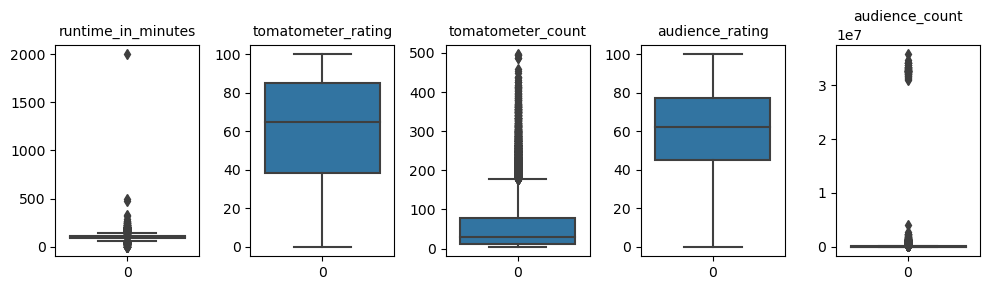

```python
num_data = data.select_dtypes('number')
print(len(data.select_dtypes('number').columns))
fig, axs = plt.subplots(1,5, figsize = (10,3))

axs = axs.flatten()

for i in range(0,len(data.select_dtypes('number').columns)):
    sns.boxplot(num_data.iloc[:,i], ax = axs[i])
    axs[i].set_title(num_data.columns[i], size = 10)

for j in range(i + 1, len(axs)):
    axs[j].axis('off')  # Hide unused axes

plt.tight_layout()
```

It looks like there is one obvious outlier for runtime in minutes

```python
display(data[data.runtime_in_minutes>1500])

#since there are only 5 tomatometer reviews let's drop that row
data.drop(data[data.runtime_in_minutes>1500].index, inplace = True)
```

|  | movie_title | rating | genre | directors | writers | cast | in_theaters_date | on_streaming_date | runtime_in_minutes | studio_name | tomatometer_status | tomatometer_rating | tomatometer_count | audience_rating | audience_count |
| --- | --- | --- | --- | --- | --- | --- | --- | --- | --- | --- | --- | --- | --- | --- | --- |
| 13539 | Terror Tract | R | Comedy | Lance W. Dreesen, Clint Hutchinson, Clint Hutc... | Clint Hutchison | John Ritter | 2000-10-18 | 2001-01-30 | 2000.0 | USA Home Entertainment | Fresh | 60 | 5 | 35.0 | 586.0 |

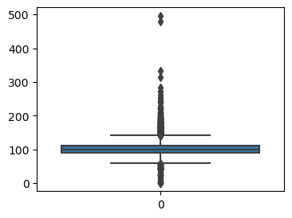

```python
plt.figure(figsize=(4, 3))
sns.boxplot(data.runtime_in_minutes)
```

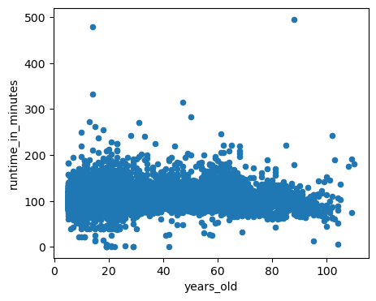

```python
#let's se a scatterplot of runtime_in_minutes based on the
data['years_old'] = 2024-pd.to_datetime(data.in_theaters_date).dt.year

data_known_release = data[~data.in_theaters_date.isna()]
plt.figure(figsize=(0.3,0.4))
data_known_release.plot.scatter(x = 'years_old', y = 'runtime_in_minutes', figsize = (5,4))
```

```python
#let's also remove movies with runtime>400
data.drop(data[data.runtime_in_minutes>400].index,inplace = True)
```

```python
#what about audience count? It seems from the boxplot that there are some extreme outliers - count > 30 000 000
len(data[data.audience_count>30000000])
```

```
50
```

since there are many movies with audience count larger than 30 000 000, let's keep these outliers for now

```python
#Let's analyze z score for that variable

len(data[abs(stats.zscore(data.audience_count))>3])
```

```
50
```

```python
#Let's create a new data set without these outliers
dataX = data[abs(stats.zscore(data.audience_count))<=3]
```

```python
dataX[abs(stats.zscore(dataX.years_old))>3]
```

|  | movie_title | rating | genre | directors | writers | cast | in_theaters_date | on_streaming_date | runtime_in_minutes | studio_name | tomatometer_status | tomatometer_rating | tomatometer_count | audience_rating | audience_count | years_old |
| --- | --- | --- | --- | --- | --- | --- | --- | --- | --- | --- | --- | --- | --- | --- | --- | --- |

Variable year_old has no outliers.

```python
dataX.rating.unique().tolist()
```

```
['PG', 'R', 'NR', 'G', 'PG-13', 'PG-13)', 'NC17', 'R)']
```

```python
#we should fix these values
data.rating.replace({'PG-13)':'PG-13','R)':'R'}, inplace = True)
dataX.rating.replace({'PG-13)':'PG-13','R)':'R'}, inplace = True)
dataX.rating.unique().tolist()
```

```
['PG', 'R', 'NR', 'G', 'PG-13', 'NC17']
```

### Feature variables analysis and correlation with target variables

First, let's create a new data set with only numerical variables and categorical variables with reasonable amount of different values in order to analyze their relationship with target variables.

```python
data1 = dataX[['rating', 'genre', 'runtime_in_minutes', 'years_old', 'tomatometer_count', 'audience_count', 'tomatometer_status',
              'tomatometer_rating', 'audience_rating']]
data1
```

|  | rating | genre | runtime_in_minutes | years_old | tomatometer_count | audience_count | tomatometer_status | tomatometer_rating | audience_rating |
| --- | --- | --- | --- | --- | --- | --- | --- | --- | --- |
| 0 | PG | Action & Adventure | 83.0 | 14.0 | 144 | 254287.0 | Rotten | 49 | 53.0 |
| 1 | R | Comedy | 90.0 | 14.0 | 140 | 11567.0 | Certified Fresh | 86 | 64.0 |
| 2 | R | Comedy | 118.0 | 45.0 | 22 | 14670.0 | Fresh | 68 | 53.0 |
| 3 | NR | Classics | 95.0 | 67.0 | 51 | 105000.0 | Certified Fresh | 100 | 97.0 |
| 4 | G | Action & Adventure | 127.0 | 70.0 | 27 | 68860.0 | Fresh | 89 | 74.0 |
| ... | ... | ... | ... | ... | ... | ... | ... | ... | ... |
| 16633 | R | Drama | 104.0 | 43.0 | 9 | 1192.0 | Rotten | 56 | 74.0 |
| 16634 | PG | Action & Adventure | 108.0 | 8.0 | 279 | 100946.0 | Certified Fresh | 97 | 92.0 |
| 16635 | NR | Action & Adventure | 142.0 | 60.0 | 9 | 7126.0 | Fresh | 78 | 87.0 |
| 16636 | PG | Classics | 139.0 | 60.0 | 21 | 30170.0 | Fresh | 95 | 91.0 |
| 16637 | PG | Action & Adventure | 117.0 | 45.0 | 7 | 4464.0 | Rotten | 57 | 62.0 |

16314 rows × 9 columns

#### RATING

Let's first look at boxplots of audience and tomatometer ratings based on movie-rating certificate

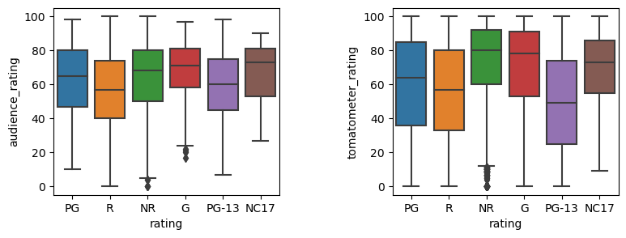

```python
#audience and tomatometer ratings based on movie-rating category

fig, axs = plt.subplots(1,2,figsize= (9,3))
sns.boxplot(x = 'rating', y = 'audience_rating', data = dataX, ax = axs[0])
sns.boxplot(x = 'rating', y = 'tomatometer_rating', data = dataX, ax = axs[1])
plt.subplots_adjust(wspace =0.5)
```

It appears that the relationship between the tomatometer and audience rating does not significantly vary with movie rating certificates. However, it can be concluded that critics generally rate NR movies the highest and PG-13-rated movies the lowest, while the audience tends to favor NC17-rated movies the most and R-rated movies the least.

Let’s look at median ratings based on movie rating certificates.

```python
data1.groupby(['rating']).audience_rating.median().sort_values(ascending = False)
```

```
rating
NC17     73.0
G        71.0
NR       68.0
PG       65.0
PG-13    60.0
R        57.0
Name: audience_rating, dtype: float64
```

```python
data1.groupby(['rating']).tomatometer_rating.median().sort_values(ascending = False)
```

```
rating
NR       80.0
G        78.0
NC17     73.0
PG       64.0
R        57.0
PG-13    49.0
Name: tomatometer_rating, dtype: float64
```

Let's perform paired t-test for each rating to see if there is actually a significant difference between audience and critics ratings based on the movie-rating certificate

```python
from scipy.stats import ttest_rel
# Group by rating certificate and perform paired t-test for each group
results = {}
for cert, group in data1.groupby('rating'):
    # Perform paired t-test for audience vs. critics ratings
    t_stat, p_value = ttest_rel(group['audience_rating'], group['tomatometer_rating'])
    results[cert] = {'t_statistic': t_stat, 'p_value': p_value}

# Display the results
res = pd.DataFrame(results)
res.round(10)
```

|  | G | NC17 | NR | PG | PG-13 | R |
| --- | --- | --- | --- | --- | --- | --- |
| t_statistic | -1.921171 | -0.282272 | -29.385072 | 7.605436 | 25.716127 | 5.575701e+00 |
| p_value | 0.055147 | 0.779351 | 0.000000 | 0.000000 | 0.000000 | 2.570000e-08 |

There is assumption about NR (non-rated) films is that they often come from smaller film productions and therefore do not receive significant audience attention, while critics tend to find them much more interesting. In other words, we’ll conduct a proportions test, comparing the proportion of reviews for NR films to other films among critics and audiences. We expect the proportion to be higher among critics.

```python
import numpy as np
from statsmodels.stats.proportion import proportions_ztest

# Count NR reviews and total reviews for critics and audience
nr_critics_reviews = data1.loc[data1['rating'] == 'NR', 'tomatometer_count'].sum()
total_critics_reviews = data1['tomatometer_count'].sum()

nr_audience_reviews = data.loc[data['rating'] == 'NR', 'audience_count'].sum()
total_audience_reviews = data['audience_count'].sum()

counts = np.array([nr_critics_reviews, nr_audience_reviews])
nobs = np.array([total_critics_reviews, total_audience_reviews])
```

```python
# Perform two-proportion z-test
z_stat, p_value = proportions_ztest(counts, nobs, alternative='larger')

# Display the results
print(f"Z-statistic: {z_stat}")
print(f"P-value: {p_value}")
```

```
Z-statistic: 1404.9818208204788
P-value: 0.0
```

Our assumption is supported by the test results.

For further analysis, let's transform 'rating' variable to numeric variable using encoding. Since these ratings can be ordered from the mildest to the strictest (except for NR - non rated movies but for simplicity reasons we will put it in the middle) we will use ordinal encoding

1. G - For all audiences
2. PG - Parental Guidance Suggested (mainly for under 10's)
3. PG-13 - Parental Guidance Suggested for children under 13
4. NR - Non rated
5. R - Under 17 not admitted without parent or guardian
6. NC-17 - Under 17 not admitted

```python
data1.rating.replace({'G':0,'PG':1, 'PG-13':2, 'NR':3, 'R':4, 'NC-17':5}, inplace = True)
```

```python
#let's also perform ANOVA test: is expected audience rating signifficantly different across movie-rating groups

model  = ols('audience_rating ~ C(rating)', data = data1).fit()
results = anova_lm(model)

# Display the results
results
```

|  | df | sum_sq | mean_sq | F | PR(>F) |
| --- | --- | --- | --- | --- | --- |
| C(rating) | 5.0 | 1.973113e+05 | 39462.265126 | 96.805566 | 7.246734e-101 |
| Residual | 16308.0 | 6.647868e+06 | 407.644588 | NaN | NaN |

#### GENRE

Let's first look at boxplot of audience ratings based on genre.

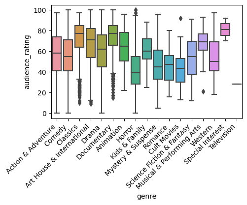

```python
plt.figure(figsize=(5,3))
sns.boxplot(x = 'genre', y = 'audience_rating', data = dataX)
plt.xticks(rotation=45, ha='right')
plt.show()
```

It seems that in general, Classics, Documentaries and Special Interes Movies have highest audience ratings.

Let's see these boxplots side by side with boxplots for the tomatometer ratings.

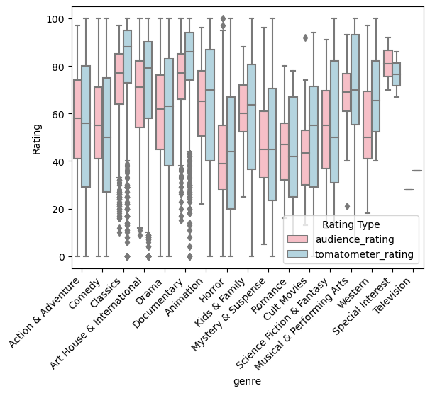

```python
data_melted = pd.melt(dataX, id_vars='genre', value_vars=['audience_rating', 'tomatometer_rating'],
                      var_name='Rating Type', value_name='Rating')

# Create the boxplot
custom_palette = {'audience_rating': 'lightpink', 'tomatometer_rating': 'lightblue'}

sns.boxplot(x='genre', y='Rating', hue='Rating Type', data=data_melted, palette=custom_palette)


#sns.boxplot(x = 'genre', y = 'tomatometer_rating', data = dataX, color='lightblue')
#sns.boxplot(x = 'genre', y = 'audience_rating', data = dataX, color='lightgreen', boxprops=dict(alpha=0.6))
plt.xticks(rotation=45, ha='right')
plt.show()
```

It seem that generally tomatometer and audience ratings are not very different by genres. However, It seems that usually westerns, cult movies, classics and art & house movies get much better ratings from tomatometer than from the audience.

Let's check if these differences are significant.

```python
t, p = stats.ttest_ind(data.loc[data.genre == 'Classics', 'tomatometer_rating'], data.loc[data.genre == 'Classics', 'audience_rating'], alternative = 'greater')
p
```

```
9.139699083906889e-21
```

Since the p value is very small, we reject the null-hypothesis, so there is statistically significant difference between tomatometer and audience ratings of Classic movies and usually tomatometer ratings are higher.

```python
t1, p1 = stats.ttest_ind(data.loc[data.genre == 'Art House & International', 'tomatometer_rating'], data.loc[data.genre == 'Art House & International', 'audience_rating'], alternative = 'greater')
t2, p2 = stats.ttest_ind(data.loc[data.genre == 'Western', 'tomatometer_rating'], data.loc[data.genre == 'Western', 'audience_rating'], alternative = 'greater')
t3, p3 = stats.ttest_ind(data.loc[data.genre == 'Cult Movies', 'tomatometer_rating'], data.loc[data.genre == 'Cult Movies', 'audience_rating'], alternative = 'greater')

print(f"p-value for Art House & International Movies is {p1}, p-value for Western movies is {p2} and p-value for Cult Movies is {p3}.")
```

```
p-value for Art House & International Movies is 2.3590330238517817e-11, p-value for Western movies is 0.12443398413901055 and p-value for Cult Movies is 0.21619935293700404.
```

Therefore, only Classics and Art House & International Movies have significantly greater rating from tomatometer than from the audience.

We can also transform this genre into dummy variables.

```python
data2 = pd.get_dummies(data1, columns = ['genre'])
data2
```

|  | rating | runtime_in_minutes | years_old | tomatometer_count | audience_count | tomatometer_status | tomatometer_rating | audience_rating | genre_Action & Adventure | genre_Animation | ... | genre_Drama | genre_Horror | genre_Kids & Family | genre_Musical & Performing Arts | genre_Mystery & Suspense | genre_Romance | genre_Science Fiction & Fantasy | genre_Special Interest | genre_Television | genre_Western |
| --- | --- | --- | --- | --- | --- | --- | --- | --- | --- | --- | --- | --- | --- | --- | --- | --- | --- | --- | --- | --- | --- |
| 0 | 1 | 83.0 | 14.0 | 144 | 254287.0 | Rotten | 49 | 53.0 | True | False | ... | False | False | False | False | False | False | False | False | False | False |
| 1 | 4 | 90.0 | 14.0 | 140 | 11567.0 | Certified Fresh | 86 | 64.0 | False | False | ... | False | False | False | False | False | False | False | False | False | False |
| 2 | 4 | 118.0 | 45.0 | 22 | 14670.0 | Fresh | 68 | 53.0 | False | False | ... | False | False | False | False | False | False | False | False | False | False |
| 3 | 3 | 95.0 | 67.0 | 51 | 105000.0 | Certified Fresh | 100 | 97.0 | False | False | ... | False | False | False | False | False | False | False | False | False | False |
| 4 | 0 | 127.0 | 70.0 | 27 | 68860.0 | Fresh | 89 | 74.0 | True | False | ... | False | False | False | False | False | False | False | False | False | False |
| ... | ... | ... | ... | ... | ... | ... | ... | ... | ... | ... | ... | ... | ... | ... | ... | ... | ... | ... | ... | ... | ... |
| 16633 | 4 | 104.0 | 43.0 | 9 | 1192.0 | Rotten | 56 | 74.0 | False | False | ... | True | False | False | False | False | False | False | False | False | False |
| 16634 | 1 | 108.0 | 8.0 | 279 | 100946.0 | Certified Fresh | 97 | 92.0 | True | False | ... | False | False | False | False | False | False | False | False | False | False |
| 16635 | 3 | 142.0 | 60.0 | 9 | 7126.0 | Fresh | 78 | 87.0 | True | False | ... | False | False | False | False | False | False | False | False | False | False |
| 16636 | 1 | 139.0 | 60.0 | 21 | 30170.0 | Fresh | 95 | 91.0 | False | False | ... | False | False | False | False | False | False | False | False | False | False |
| 16637 | 1 | 117.0 | 45.0 | 7 | 4464.0 | Rotten | 57 | 62.0 | True | False | ... | False | False | False | False | False | False | False | False | False | False |

16314 rows × 25 columns

```python
data2.tomatometer_status.replace({'Rotten':0, 'Fresh':1, 'Certified Fresh':2}, inplace = True)
data2
```

|  | rating | runtime_in_minutes | years_old | tomatometer_count | audience_count | tomatometer_status | tomatometer_rating | audience_rating | genre_Action & Adventure | genre_Animation | ... | genre_Drama | genre_Horror | genre_Kids & Family | genre_Musical & Performing Arts | genre_Mystery & Suspense | genre_Romance | genre_Science Fiction & Fantasy | genre_Special Interest | genre_Television | genre_Western |
| --- | --- | --- | --- | --- | --- | --- | --- | --- | --- | --- | --- | --- | --- | --- | --- | --- | --- | --- | --- | --- | --- |
| 0 | 1 | 83.0 | 14.0 | 144 | 254287.0 | 0 | 49 | 53.0 | True | False | ... | False | False | False | False | False | False | False | False | False | False |
| 1 | 4 | 90.0 | 14.0 | 140 | 11567.0 | 2 | 86 | 64.0 | False | False | ... | False | False | False | False | False | False | False | False | False | False |
| 2 | 4 | 118.0 | 45.0 | 22 | 14670.0 | 1 | 68 | 53.0 | False | False | ... | False | False | False | False | False | False | False | False | False | False |
| 3 | 3 | 95.0 | 67.0 | 51 | 105000.0 | 2 | 100 | 97.0 | False | False | ... | False | False | False | False | False | False | False | False | False | False |
| 4 | 0 | 127.0 | 70.0 | 27 | 68860.0 | 1 | 89 | 74.0 | True | False | ... | False | False | False | False | False | False | False | False | False | False |
| ... | ... | ... | ... | ... | ... | ... | ... | ... | ... | ... | ... | ... | ... | ... | ... | ... | ... | ... | ... | ... | ... |
| 16633 | 4 | 104.0 | 43.0 | 9 | 1192.0 | 0 | 56 | 74.0 | False | False | ... | True | False | False | False | False | False | False | False | False | False |
| 16634 | 1 | 108.0 | 8.0 | 279 | 100946.0 | 2 | 97 | 92.0 | True | False | ... | False | False | False | False | False | False | False | False | False | False |
| 16635 | 3 | 142.0 | 60.0 | 9 | 7126.0 | 1 | 78 | 87.0 | True | False | ... | False | False | False | False | False | False | False | False | False | False |
| 16636 | 1 | 139.0 | 60.0 | 21 | 30170.0 | 1 | 95 | 91.0 | False | False | ... | False | False | False | False | False | False | False | False | False | False |
| 16637 | 1 | 117.0 | 45.0 | 7 | 4464.0 | 0 | 57 | 62.0 | True | False | ... | False | False | False | False | False | False | False | False | False | False |

16314 rows × 25 columns

### Feature Selection

Here, we will select only feature variables which best explain the relationship of the independent variables with respect to the target variables, 'tomatometer_rating' and 'audience_rating'. Strength of these relationships will be explained by correlations table, heat maps and pair plots.

```python
#Variables with numeric values

data_num = data.select_dtypes('number')
data_num
```

|  | runtime_in_minutes | tomatometer_rating | tomatometer_count | audience_rating | audience_count | years_old |
| --- | --- | --- | --- | --- | --- | --- |
| 0 | 83.0 | 49 | 144 | 53.0 | 254287.0 | 14.0 |
| 1 | 90.0 | 86 | 140 | 64.0 | 11567.0 | 14.0 |
| 2 | 118.0 | 68 | 22 | 53.0 | 14670.0 | 45.0 |
| 3 | 95.0 | 100 | 51 | 97.0 | 105000.0 | 67.0 |
| 4 | 127.0 | 89 | 27 | 74.0 | 68860.0 | 70.0 |
| ... | ... | ... | ... | ... | ... | ... |
| 16633 | 104.0 | 56 | 9 | 74.0 | 1192.0 | 43.0 |
| 16634 | 108.0 | 97 | 279 | 92.0 | 100946.0 | 8.0 |
| 16635 | 142.0 | 78 | 9 | 87.0 | 7126.0 | 60.0 |
| 16636 | 139.0 | 95 | 21 | 91.0 | 30170.0 | 60.0 |
| 16637 | 117.0 | 57 | 7 | 62.0 | 4464.0 | 45.0 |

16364 rows × 6 columns

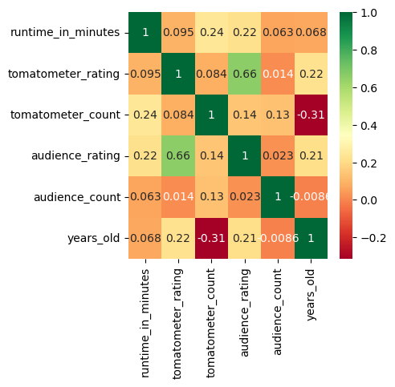

```python
plt.figure(figsize=(4,4))
sns.heatmap(data_num.corr(),annot=True,cmap='RdYlGn')

plt.show()
```

It seems from the heat map and correlation values that corelation, although week, exists between runtime in minutes and audience rating as well as between the age of the movie and audience rating. However there is strong correlation between audience and tomatometer rating but that is not something we consider since we want to see how movie features affect the audience and the tomatometer rating.

Tomatometer rating isn't significantly correlated with other feature variables except for week correlation with age of the movie.

We will keep all features for now.

```python
data2.columns
```

```
Index(['rating', 'runtime_in_minutes', 'years_old', 'tomatometer_count',
       'audience_count', 'tomatometer_status', 'tomatometer_rating',
       'audience_rating', 'genre_Action & Adventure', 'genre_Animation',
       'genre_Art House & International', 'genre_Classics', 'genre_Comedy',
       'genre_Cult Movies', 'genre_Documentary', 'genre_Drama', 'genre_Horror',
       'genre_Kids & Family', 'genre_Musical & Performing Arts',
       'genre_Mystery & Suspense', 'genre_Romance',
       'genre_Science Fiction & Fantasy', 'genre_Special Interest',
       'genre_Television', 'genre_Western'],
      dtype='object')
```

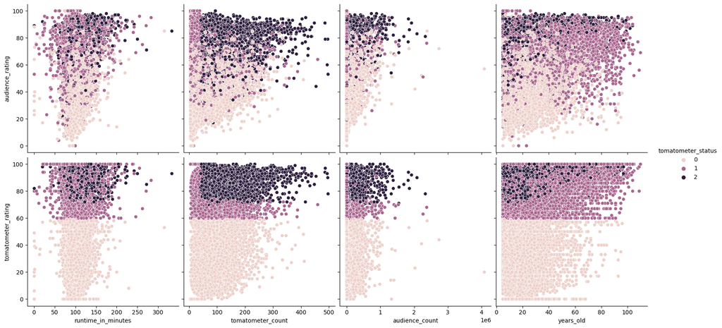

```python
### BEGIN SOLUTION

sns.pairplot(data=data2, x_vars = data_num[['runtime_in_minutes','tomatometer_count','audience_count','years_old']].columns,
            y_vars=['audience_rating','tomatometer_rating'], size=4, hue = 'tomatometer_status');
### END SOLUTION
```

#### skewness of the target variables?

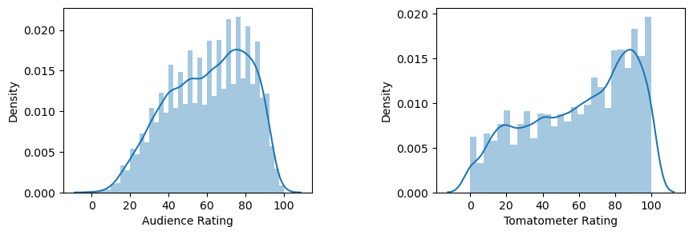

```python
fig, axes = plt.subplots(1, 2, figsize = (10,3))
sns.distplot(data2.audience_rating, ax = axes[0])
axes[0].tick_params(axis='x', labelsize=10)  # Set x-ticks font size
axes[0].tick_params(axis='y', labelsize=10)  # Set y-ticks font size


sns.distplot(data2.tomatometer_rating, ax = axes[1])
axes[1].tick_params(axis='x', labelsize=10)  # Set x-ticks font size
axes[1].tick_params(axis='y', labelsize=10)  # Set y-ticks font size


axes[0].set_xlabel('Audience Rating', fontsize=10)  # Adjust x-axis label font size
axes[1].set_xlabel('Tomatometer Rating', fontsize=10)

axes[0].set_ylabel('Density', fontsize = 10)
axes[1].set_ylabel('Density', fontsize = 10)
plt.subplots_adjust(wspace=0.5)
```

```python
[data2.audience_rating.skew(), data2.tomatometer_rating.skew()]
```

```
[-0.3056622650999392, -0.41262178149148604]
```

Since the skewnees is in range [-0.5, 0.5] we can say that both the audience rating and tomatometer rating target variables are symetrical enough.

```python
data_num.loc[[15659, 16316],:]
```

|  | runtime_in_minutes | tomatometer_rating | tomatometer_count | audience_rating | audience_count | years_old |
| --- | --- | --- | --- | --- | --- | --- |
| 15659 | 81.0 | 100 | 22 | 82.0 | 375.0 | 7.0 |
| 16316 | 90.0 | 95 | 43 | 94.0 | 22600.0 | 67.0 |

##### LINEAR REGRESSION - AUDIENCE RATING

```python
data3 = data_num.dropna()

# Create and fit the model
import statsmodels.api as sm
X = sm.add_constant(data3.drop(['audience_rating', 'tomatometer_rating'], axis=1))
model = sm.OLS(data3.audience_rating, X).fit()

print(model.summary())
```

```
                            OLS Regression Results
==============================================================================
Dep. Variable:        audience_rating   R-squared:                       0.116
Model:                            OLS   Adj. R-squared:                  0.115
Method:                 Least Squares   F-statistic:                     511.9
Date:                Sun, 10 Nov 2024   Prob (F-statistic):               0.00
Time:                        18:23:12   Log-Likelihood:                -68469.
No. Observations:               15657   AIC:                         1.369e+05
Df Residuals:                   15652   BIC:                         1.370e+05
Df Model:                           4
Covariance Type:            nonrobust
======================================================================================
                         coef    std err          t      P>|t|      [0.025      0.975]
--------------------------------------------------------------------------------------
const                 33.1826      0.834     39.811      0.000      31.549      34.816
runtime_in_minutes     0.1712      0.008     20.917      0.000       0.155       0.187
tomatometer_count      0.0548      0.003     21.826      0.000       0.050       0.060
audience_count     -1.031e-07   8.33e-08     -1.237      0.216   -2.66e-07    6.02e-08
years_old              0.2695      0.008     31.994      0.000       0.253       0.286
==============================================================================
Omnibus:                      862.343   Durbin-Watson:                   1.911
Prob(Omnibus):                  0.000   Jarque-Bera (JB):              419.863
Skew:                          -0.214   Prob(JB):                     6.73e-92
Kurtosis:                       2.321   Cond. No.                     1.01e+07
==============================================================================

Notes:
[1] Standard Errors assume that the covariance matrix of the errors is correctly specified.
[2] The condition number is large, 1.01e+07. This might indicate that there are
strong multicollinearity or other numerical problems.
```

```python
#Let's sketch predicted vs real values of audience ratings
```

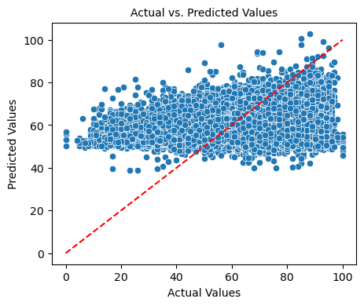

```python
y_test = data3.audience_rating
y_pred = model.fittedvalues
plt.figure(figsize=(5, 4))
sns.scatterplot(x=y_test, y=y_pred)
plt.plot([y_test.min(), y_test.max()], [y_test.min(), y_test.max()], color='red', linestyle='--')  # 45-degree line
plt.xlabel("Actual Values", fontsize = 10)
plt.ylabel("Predicted Values", fontsize = 10)
plt.title("Actual vs. Predicted Values", fontsize = 10)

plt.xticks(size = 10)
plt.yticks(size = 10)
plt.show()
```

This plot shows how closely the predictions match the actual values. A perfect model would have all points lying on the 45-degree diagonal line. Therefore, our model is not that great.

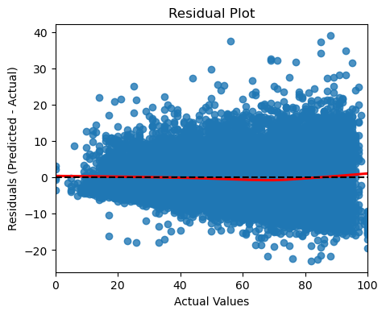

```python
#A residual plot can help check if the residuals (errors) are randomly distributed.
#It's a good diagnostic tool to assess the quality of a regression model.

plt.figure(figsize=(5, 4))
sns.residplot(x=y_test, y=y_pred - y_test, lowess=True, line_kws={'color': 'red'})
plt.axhline(y=0, color='black', linestyle='--')
plt.xlabel("Actual Values")
plt.ylabel("Residuals (Predicted - Actual)")
plt.title("Residual Plot")
plt.show()
```

If the residuals are randomly scattered around the horizontal line (y=0), it indicates a good fit. Therefore, our model is not too bad.

##### LINEAR REGRESSION - TOMATOMETER RATING

```python
X = sm.add_constant(data3.drop(['audience_rating', 'tomatometer_rating'], axis=1))
model = sm.OLS(data3.tomatometer_rating, X).fit()

print(model.summary())
```

```
                            OLS Regression Results
==============================================================================
Dep. Variable:     tomatometer_rating   R-squared:                       0.081
Model:                            OLS   Adj. R-squared:                  0.081
Method:                 Least Squares   F-statistic:                     346.1
Date:                Sun, 10 Nov 2024   Prob (F-statistic):          5.37e-286
Time:                        18:23:21   Log-Likelihood:                -74032.
No. Observations:               15657   AIC:                         1.481e+05
Df Residuals:                   15652   BIC:                         1.481e+05
Df Model:                           4
Covariance Type:            nonrobust
======================================================================================
                         coef    std err          t      P>|t|      [0.025      0.975]
--------------------------------------------------------------------------------------
const                 38.8458      1.189     32.669      0.000      36.515      41.176
runtime_in_minutes     0.0701      0.012      6.004      0.000       0.047       0.093
tomatometer_count      0.0701      0.004     19.582      0.000       0.063       0.077
audience_count     -1.092e-07   1.19e-07     -0.919      0.358   -3.42e-07    1.24e-07
years_old              0.4017      0.012     33.431      0.000       0.378       0.425
==============================================================================
Omnibus:                     2324.562   Durbin-Watson:                   1.901
Prob(Omnibus):                  0.000   Jarque-Bera (JB):              802.097
Skew:                          -0.330   Prob(JB):                    6.71e-175
Kurtosis:                       2.109   Cond. No.                     1.01e+07
==============================================================================

Notes:
[1] Standard Errors assume that the covariance matrix of the errors is correctly specified.
[2] The condition number is large, 1.01e+07. This might indicate that there are
strong multicollinearity or other numerical problems.
```

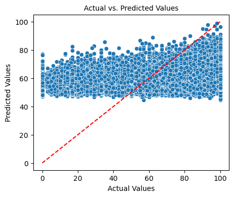

```python
y_test = data3.tomatometer_rating
y_pred = model.fittedvalues
plt.figure(figsize=(5, 4))
sns.scatterplot(x=y_test, y=y_pred)
plt.plot([y_test.min(), y_test.max()], [y_test.min(), y_test.max()], color='red', linestyle='--')  # 45-degree line
plt.xlabel("Actual Values", fontsize = 10)
plt.ylabel("Predicted Values", fontsize = 10)
plt.title("Actual vs. Predicted Values", fontsize = 10)

plt.xticks(size = 10)
plt.yticks(size = 10)
plt.show()
```

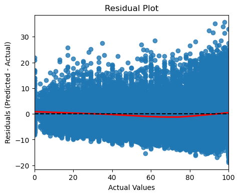

```python
#A residual plot can help check if the residuals (errors) are randomly distributed.
#It's a good diagnostic tool to assess the quality of a regression model.

plt.figure(figsize=(5, 4))
sns.residplot(x=y_test, y=y_pred - y_test, lowess=True, line_kws={'color': 'red'})
plt.axhline(y=0, color='black', linestyle='--')
plt.xlabel("Actual Values")
plt.ylabel("Residuals (Predicted - Actual)")
plt.title("Residual Plot")
plt.show()
```

To conclude, the linear regression models for predicting audience and tomatometer ratings do not perform well, as indicated by the low coefficients of determination. This is also evident from the scatter plots, which show a lack of strong relationships between the predictions and the actual ratings. This outcome is expected, given that we observed low correlations between the feature variables and the target ratings earlier in the analysis.